# Assignment 4

Weijie Jaycee Xin

## Background

The project aims to examine the health situation in New York City, mainly focusing on the health outcome data distribution and the relationship between certain social determinants and the health outcomes. With the detailed examination and insightful findings, it would benefit the implementation of the related health policies and the community health programs.

```r
library(ggplot2)
library(readxl)
library(extrafont)
setwd('/Users/admin/Desktop/DataViz')
```

## Theming

```r
the_theme <- theme(plot.title = element_text(face="bold", size=15, family='Verdana'),
                   plot.subtitle = element_text(size=10, margin=margin(b=10)),
                   plot.caption = element_text(size=8, margin=margin(t=10)),

                   axis.title = element_text(size=10),
                   axis.title.x = element_text(margin=margin(t=10)),
                   axis.title.y = element_text(margin=margin(r=10)),
                   axis.text = element_text(size=8),
                   axis.text.x = element_text(margin=margin(t=3)),

                   plot.margin=unit(c(1,1,1,1),"cm"),

                   panel.background = element_rect(fill = "#e9e9e9"),
                   panel.grid.major.y=element_line(color='white', size=0.25),
                   panel.grid.minor.y=element_blank(),
                   panel.grid.major.x = element_line(color='white', size=0.25),
                   panel.grid.minor.x=element_blank(),

                   legend.background = element_rect(fill="#e9e9e9"),
                   legend.key = element_blank(),
                   legend.title = element_text(family="Verdana", size=9),
                   legend.text = element_text(family="Verdana", size=8),
                   legend.position = "bottom",

                   axis.ticks=element_blank())
default_color_palette = 'Set2'
default_discrete_color = c('#F08080', '#ADD8E6', '#FFFACD', '#90EE90', '#E6E6FA')
default_continuous_color = c('#DB7093', '#DDA0DD', '#FFC0CB', '#FFE4E1', '#FFF0F5')
```

## Plot 1

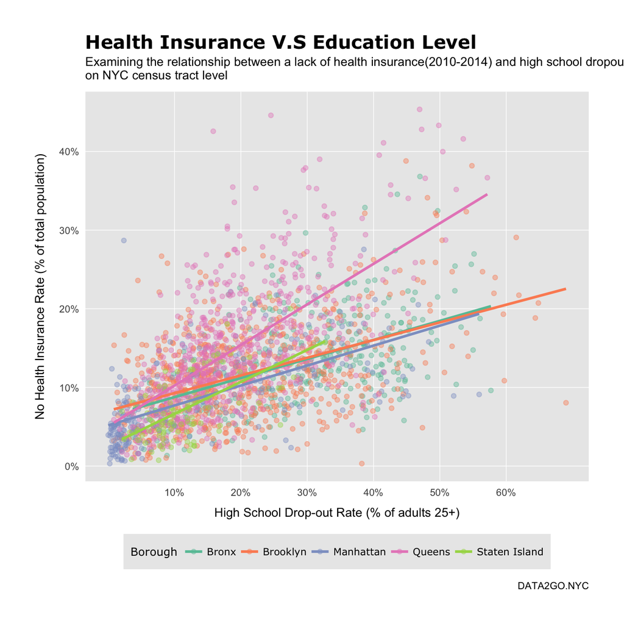

```r
g1 <- read_excel('G2.xlsx')

ggplot(data=g1, aes(x=no_hs_tract, y=health_insurance_uninsured_tract, color=GEO)) +
  scale_colour_brewer(palette = "Set2") +
  geom_point(alpha=0.4) +
  geom_smooth(method='lm', se=FALSE)+
  scale_x_continuous(breaks=c(10, 20, 30, 40, 50, 60),
                     labels=c("10%","20%", "30%", "40%", "50%","60%")) +
  scale_y_continuous(breaks=c(0, 10, 20, 30, 40),
                     labels=c('0%', "10%", "20%", "30%", "40%")) +

  labs(y = "No Health Insurance Rate (% of total population)", x = "High School Drop-out Rate (% of adults 25+)",
       title="Health Insurance V.S Education Level",
       subtitle="Examining the relationship between a lack of health insurance(2010-2014) and high school dropout(2011-2015) \non NYC census tract level",
       caption="DATA2GO.NYC") +
       the_theme +
       guides(color=guide_legend("Borough"))
```

## Plot 2

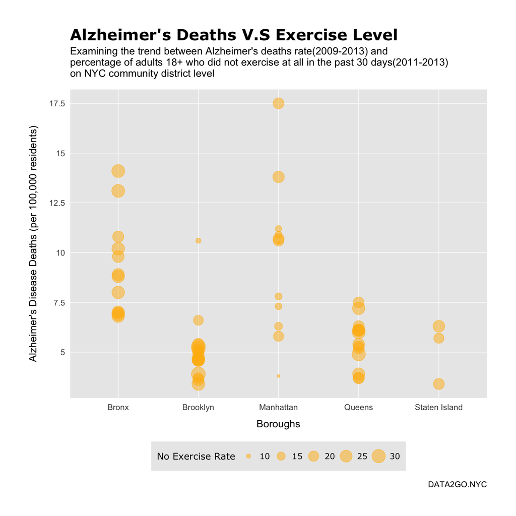

```r
g2 <- read_excel('G1.xlsx')

ggplot(data=g2, aes(x=Borough, y = alzheimers_deaths_cd, size=No_Exercise_Rate)) +
  geom_point(alpha=0.5, color='darkgoldenrod1') +
  scale_y_continuous(breaks=c(0, 2.5, 5, 7.5, 10, 12.5, 15, 17.5),
                     labels=c('0', "2.5", "5", "7.5", "10", '12.5', '15', '17.5')) +

  labs(y = "Alzheimer's Disease Deaths (per 100,000 residents)", x = "Boroughs",
       title="Alzheimer's Deaths V.S Exercise Level",
       subtitle="Examining the trend between Alzheimer's deaths rate(2009-2013) and \npercentage of adults 18+ who did not exercise at all in the past 30 days(2011-2013) \non NYC community district level",
       caption="DATA2GO.NYC") +
       the_theme +
       guides(size=guide_legend("No Exercise Rate"))
```

**Summary** The graph is designed to examine the relationship between the social determinant variable *No Exercise Rate(2011-2013)*, which is percentage of adults 18+ who did not exercise at all in the past 30 days, and the health outcome variable *Alzheimer’s Deaths per 100,000 residents(2009-2013)*. The data are collected on the community district level of NYC, with 59 data points. From the graph we can see, generally, there is no strong relationship between the two variables among all five boroughs. In Bronx, Queens and Staten Island, *No Exercise Rate* barely changes with the increase of *Alzheimer’s Deaths*. In Brooklyn, there is a weak negative relationship between the two variables, while in Manhattan, there is a weak positive relationship, which is the relationship people may presume.

## Plot 3

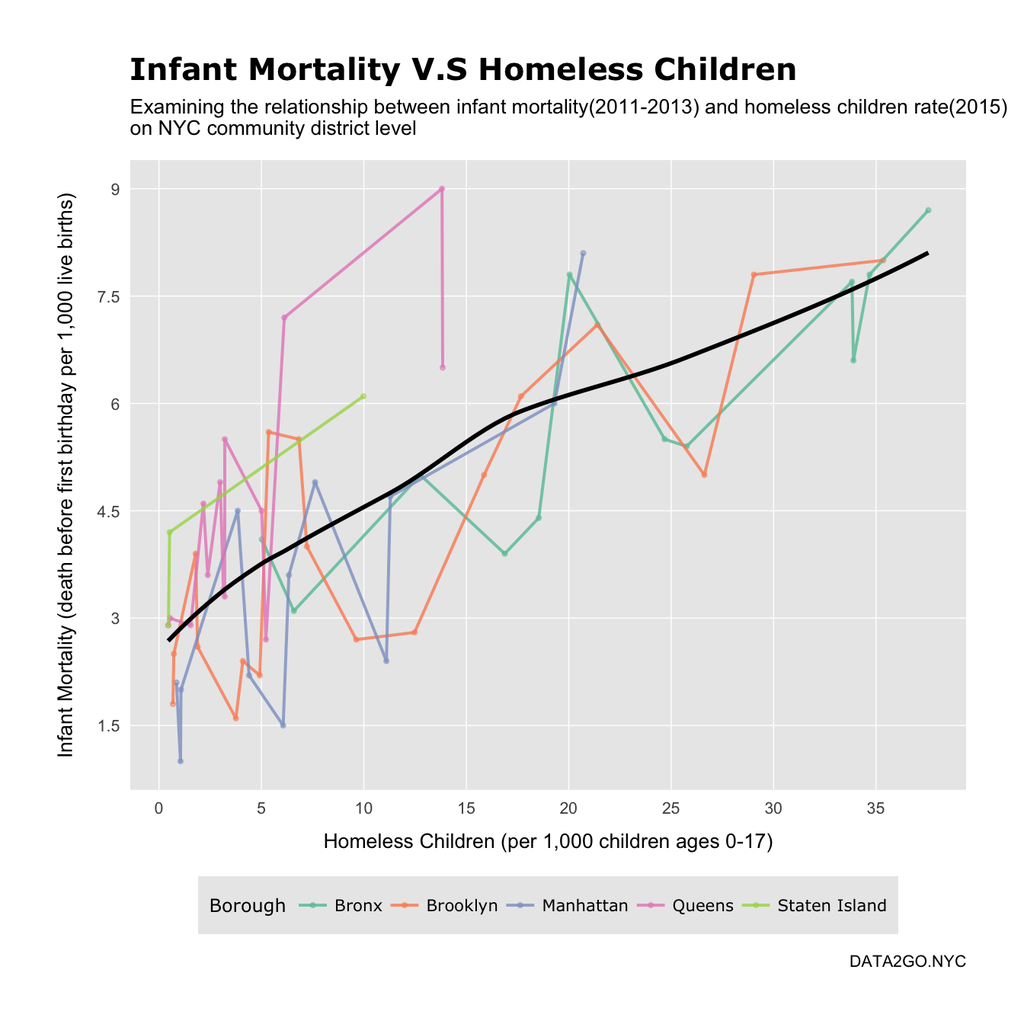

```r
g3 <- read_excel('G4.xlsx')

ggplot(g3, aes(x=homeless_children_rate_cd, y=infant_mortality_cd)) +
  geom_point(size=0.8, alpha=0.5, aes(color=Borough)) +
  geom_line(size=0.7, alpha=0.8, aes(color=Borough)) +
  scale_colour_brewer(palette = "Set2") +
  geom_smooth(method = 'loess', se=FALSE, color='black') +
  scale_x_continuous(breaks=c(0, 5, 10, 15, 20, 25, 30, 35),
                     labels=c('0', "5","10", "15", "20", "25","30",'35')) +
  scale_y_continuous(breaks=c(1.5, 3, 4.5, 6, 7.5, 9),
                     labels=c("1.5", "3", "4.5", "6", "7.5", '9')) +

  labs(y = "Infant Mortality (death before first birthday per 1,000 live births)", x = "Homeless Children (per 1,000 children ages 0-17)",
       title="Infant Mortality V.S Homeless Children",
       subtitle="Examining the relationship between infant mortality(2011-2013) and homeless children rate(2015) \non NYC community district level",
       caption="DATA2GO.NYC") +
       the_theme
```

**Summary** The graph is designed to examine the relationship between the social determinant variable *Homeless Children(2015)* and the health outcome variable *Infant Mortality(2011-2013)*. The data are collected on the community district level of NYC, with 59 data points. From the graph we can see, there is a positive relationship between the two variables among all five boroughs. Bronx and Brooklyn have clearer and stronger trends compared to the other three boroughs.

## Plot 4

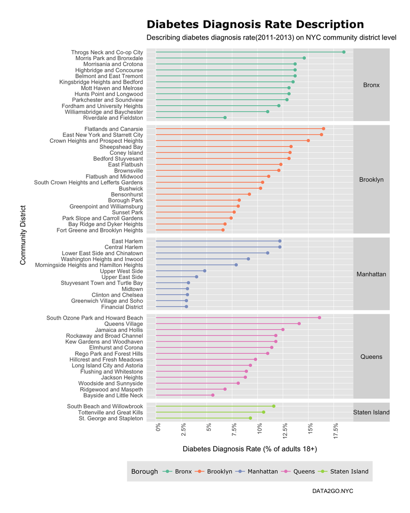

```r
g4 <- read_excel('G1.xlsx')

ggplot(data=g4, aes(x=diabetes, y = reorder(GEO_DISPLAY_NAME, diabetes), color=Borough)) +
  scale_colour_brewer(palette = "Set2") +
  geom_segment(aes(yend=GEO_DISPLAY_NAME,xend=0)) +
  geom_point() +
  facet_grid(Borough ~ ., scales="free_y", space="free_y") +
  scale_x_continuous(breaks=c(0, 2.5, 5, 7.5, 10, 12.5, 15, 17.5),
                     labels=c('0%', "2.5%", "5%", "7.5%", "10%", '12.5%', '15%', '17.5%')) +

  labs(y = "Community District", x = "Diabetes Diagnosis Rate (% of adults 18+)",
       title="Diabetes Diagnosis Rate Description",
       subtitle="Describing diabetes diagnosis rate(2011-2013) on NYC community district level",
       caption="DATA2GO.NYC") +
       the_theme +
       theme(axis.text.x = element_text(angle=90, hjust=1, margin=margin(t=-1), size=8),
             strip.text.y = element_text(angle=0, margin=margin(l=0)))
```

**Summary** The graph is designed to examine the distribution of *Diabetes Diagnosis Rate(2011-2013)*, which is the percentage of adults 18+ who have ever been told they have diabetes. The data are collected on the community district level of NYC, with 59 data points. From the graph we can see, Bronx, Brooklyn, Queens and Staten Island have similar distributions, while Manhattan has an overall lower rate distribution.

## Plot 5

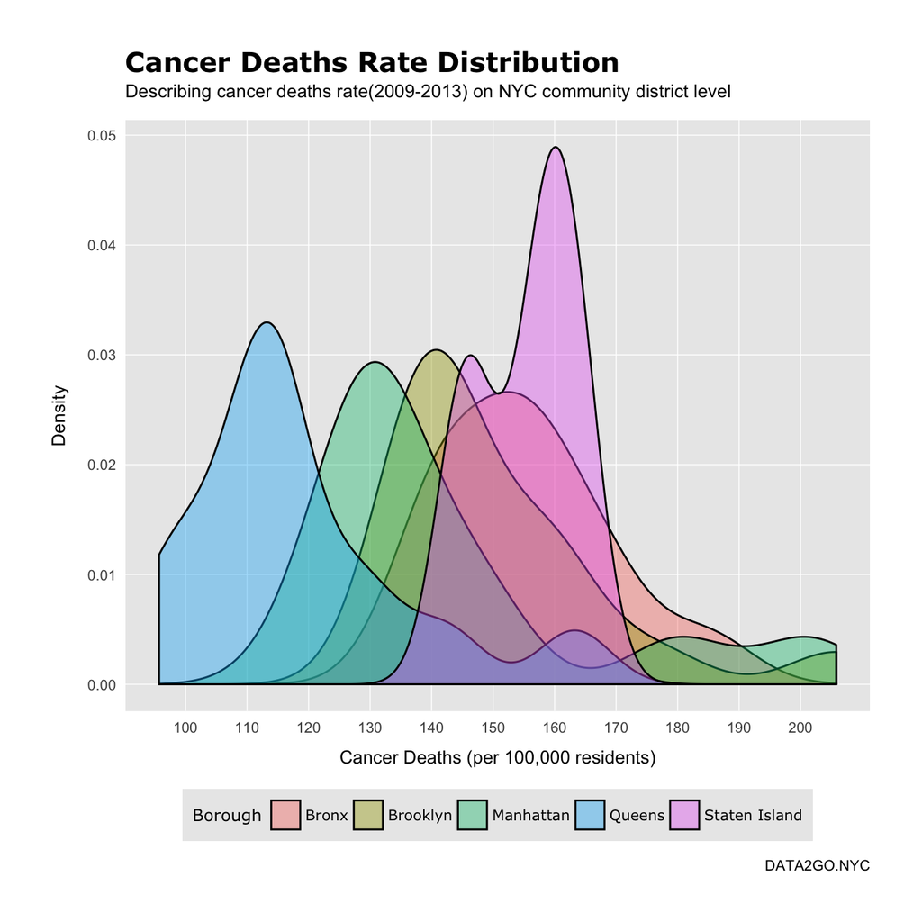

```r
g5 <- read_excel('G4.xlsx')

ggplot(data=g5, aes(x=cancer_deaths_cd, fill=Borough)) +
  scale_colour_brewer(palette = "Set2") +
  geom_density(alpha=0.4) +
  scale_x_continuous(breaks=c(100, 110, 120, 130, 140, 150, 160, 170, 180, 190, 200),
                     labels=c('100', '110', "120", "130", "140", "150", '160', '170', '180', '190', '200')) +

  labs(y = "Density", x = "Cancer Deaths (per 100,000 residents)",
       title="Cancer Deaths Rate Distribution",
       subtitle="Describing cancer deaths rate(2009-2013) on NYC community district level",
       caption="DATA2GO.NYC") +
       the_theme
```

**Summary** The graph is designed to examine the distribution of *Cancer Deaths Rate(2009-2013)*. Note that the death rate for malignant neoplasms (cancers) is adjusted to account for variations in the age structure of the populations. The data are collected on the community district level of NYC, with 59 data points. From the graph we can see, Bronx, Brooklyn and Manhattan have similar bell-shaped distributions, while Queens is right-skewed, and Staten Island has two peaks.

## Plot 6

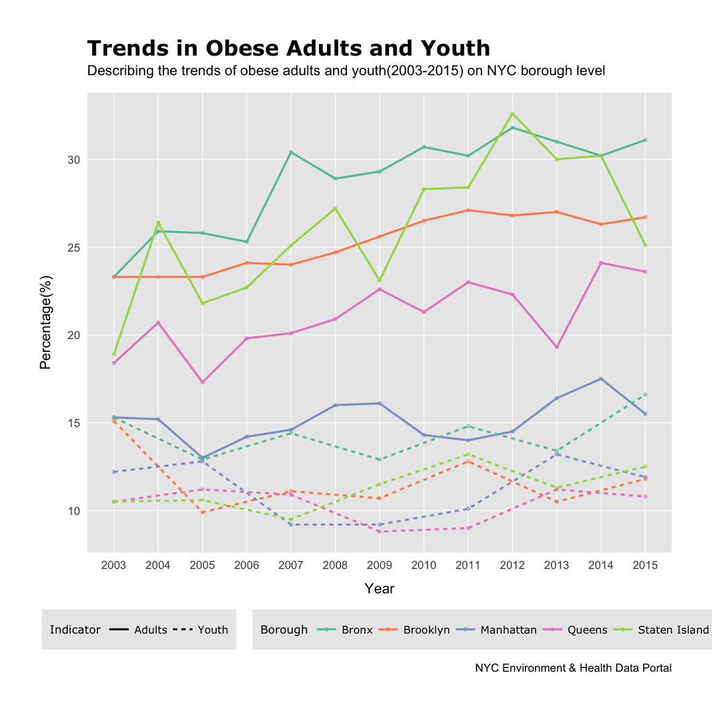

```r
g6 <- read_excel('G6.xlsx')

ggplot(g6, aes(x=Year, y=Percent, group=interaction(Borough, Indicator), colour=Borough)) +
  geom_point(size=0.8, alpha=0.5) +
  geom_line(size=0.7, aes(linetype=Indicator)) +
  scale_colour_brewer(palette = "Set2") +
  scale_x_continuous(breaks=seq(2003, 2015),
                     labels=seq(2003, 2015)) +

  labs(y = "Percentage(%)", x = "Year",
       title="Trends in Obese Adults and Youth",
       subtitle="Describing the trends of obese adults and youth(2003-2015) on NYC borough level",
       caption="NYC Environment & Health Data Portal") +
       the_theme +
       theme(legend.title = element_text(family="Verdana", size=8),
             legend.text = element_text(family="Verdana", size=7.5))
```

## Plot 7

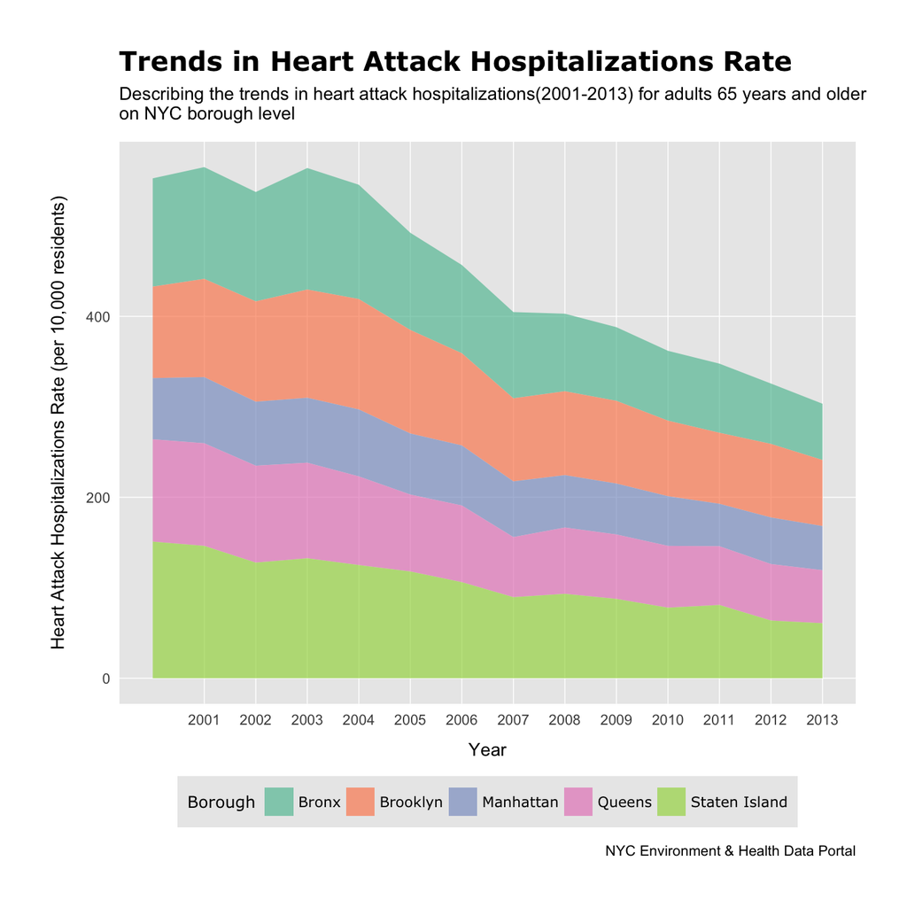

```r
g7 <- read_excel('G7.xlsx')

ggplot(g7, aes(x=Year, y=AdjRate2, fill=Borough)) +
  scale_fill_brewer(palette = "Set2") +
  geom_area(position = "stack", alpha=0.7) +
  scale_x_continuous(breaks=seq(2001, 2013),
                     labels=seq(2001, 2013)) +
  labs(y = "Heart Attack Hospitalizations Rate (per 10,000 residents)", x = "Year",
       title="Trends in Heart Attack Hospitalizations Rate",
       subtitle="Describing the trends in heart attack hospitalizations(2001-2013) for adults 65 years and older \non NYC borough level",
       caption="NYC Environment & Health Data Portal") +
  the_theme
```